# cp2021-F03-Q1-c

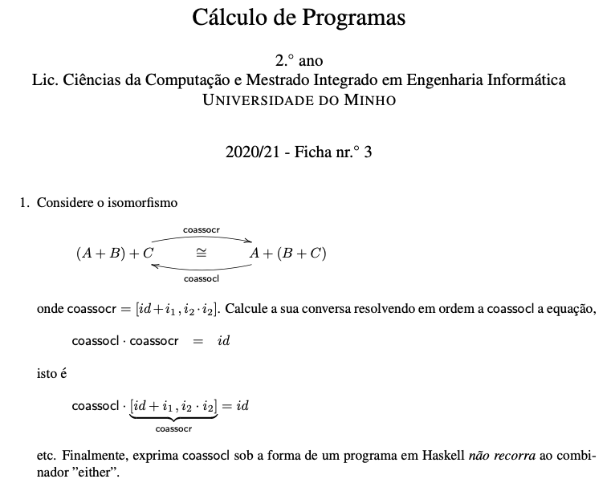

### Resolução

Vamos começar por desenhar o diagrama que testemunha o isomorfismo.

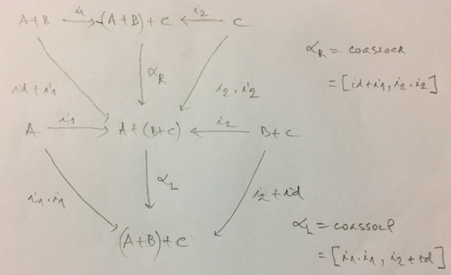

Sendo $coassocl = [i_1 \cdot i_1, i_2 + id]$, vamos então demonstrar que $coassocl \cdot coassocr = id$

$[i_1 . i_1, i_2 + id] . [id + i_1, i_2 . i_2]$

{ fusão-+, **lei (20)** }

$[ [i_1 \cdot i_1, i_2 + id] \cdot (id + i_1) \ , \ [i_1 . i_1, i_2 + id] \cdot (i_2 \cdot i_2) ]$

{ assoc-comp, **lei (2)** }

$[ [i_1 \cdot i_1, i_2 + id] \cdot (id + i_1) \ , \ ([i_1 . i_1, i_2 + id] \cdot i_2) . i_2) ]$

{ cancelamento-+, **lei (18)** }

$[ [i_1 \cdot i_1, i_2 + id] \cdot (id + i_1) \ , \ (i_2 + id) \cdot i_2) ]$

{ natural-$i_2$, **lei (24)** }

$[ [i_1 \cdot i_1, i_2 + id] \cdot (id + i_1) \ , \ i_2 \cdot id ]$

{ absorção-+, **lei (22)**; natural-id, **lei(1)** }

$[ [i_1 \cdot i_1 \cdot id, (i_2 + id) \cdot i_1] \ , \ i_2 ]$

{ natural-id, **lei(1)** ; natural_$i_1$, **lei (23)** }

$[ [i_1 \cdot i_1, i_1 \cdot i_2] \ , \ i_2 ]$

{ fusão-+, **lei (20)** }

$[ i_1 \cdot [i_1, i_2] \ , \ i_2 ]$

{ reflexão-+, **lei (19)** }

$[ i_1 \cdot id \ , \ i_2 ]$

{ natural-id, **lei(1)** }

$[ i_1 \ , \ i_2 ]$

{ reflexão-+, **lei (19)** }

$id$

### Haskell

```haskell
:load ../src/Cp.hs

-- pointfree

coassoclPF = either (i1 . i1) (i2 -|- id)

-- pointwise

coassoclPW (Left a) = Left . Left $ a
coassoclPW (Right (Left a)) = Left . Right $ a
coassoclPW (Right (Right a)) = Right a
```

```haskell
-- type checking

:t coassoclPF
:t coassoclPW
```

coassoclPF :: forall a b1 b2. Either a (Either b1 b2) -> Either (Either a b1) b2

coassoclPW :: forall a b1 b2. Either a (Either b1 b2) -> Either (Either a b1) b2